# EDA_Biathlon.Rmd

Group_B

10/05/2020

# Task

Compose a report with a descriptive analysis of the data. Investigate which variables affect the skiing speed of the athletes. Use basic statistics as well as appropriate plots to illustrate the effects of environmental conditions or course profiles on skiing speed.

# Read data

At first read the data set into the workspace either via the console or the “import dataset” dialog in environment menu (right upper pane).

#Extract Data

## Data Types

$ Factors: 11$,$int: 4$, $num: 9$

```r
summary(dat)
```

```
##       date           season     competition type
##  9-12-11:  119   12-13  :1872   I:3065      C: 1992
##  12-3-3 :  116   16-17  :1843   M:1448      O:  739
##  12-3-7 :  114   8-9    :1823   P:4183      W:14989
##  13-2-13:  113   9-10   :1808   S:9024
##  13-2-9 :  113   17-18  :1770
##  10-1-13:  112   11-12  :1749
##  (Other):17033   (Other):6855
##                  name           nation           rank        course.rank
##  MÄKÄRÄINEN Kaisa  :  248   GER    : 1378   Min.   :  1.0   Min.   :  1.00
##  DORIN HABERT Marie:  217   RUS    : 1197   1st Qu.: 18.0   1st Qu.: 18.00
##  SKARDINO Nadezhda :  212   FRA    : 1131   Median : 37.0   Median : 36.00
##  DOMRACHEVA Darya  :  202   NOR    : 1071   Mean   : 40.7   Mean   : 39.78
##  GREGORIN Teja     :  200   UKR    : 1050   3rd Qu.: 60.0   3rd Qu.: 58.00
##  VITKOVA Veronika  :  199   BLR    :  958   Max.   :119.0   Max.   :119.00
##  (Other)           :16442   (Other):10935
##     tot.time     course.time                location      elevation
##  Min.   :   0   Min.   :1032   Östersund        :2360   Min.   :  57.0
##  1st Qu.:1390   1st Qu.:1235   Hochfilzen       :2142   1st Qu.: 330.0
##  Median :1726   Median :1460   Ruhpolding       :1846   Median : 714.0
##  Mean   :1813   Mean   :1629   Oslo Holmenkollen:1637   Mean   : 734.9
##  3rd Qu.:2273   3rd Qu.:1859   Antholz          :1579   3rd Qu.:1019.0
##  Max.   :4257   Max.   :3465   Pokljuka         :1288   Max.   :1630.0
##                                (Other)          :6868
##   height.diff     max.climb       total.climb         birthday
##  Min.   :16.0   Min.   : 10.00   Min.   : 59.0   18.1.1986:  340
##  1st Qu.:28.0   1st Qu.: 19.00   1st Qu.:234.0   11.1.1983:  253
##  Median :36.0   Median : 23.00   Median :271.0   19.6.1986:  217
##  Mean   :35.8   Mean   : 26.25   Mean   :298.2   27.3.1985:  212
##  3rd Qu.:43.0   3rd Qu.: 31.00   3rd Qu.:355.0   3.8.1986 :  204
##  Max.   :57.0   Max.   :118.00   Max.   :645.0   (Other)  :16493
##  NA's   :57     NA's   :57       NA's   :57      NA's     :    1
##       snow.conditions snow.temperature  air.temperature
##  Packed       :4624   Min.   :-17.000   Min.   :-18.800
##  Packed powder:2299   1st Qu.: -3.500   1st Qu.: -4.800
##  Hard         :2105   Median : -1.000   Median : -0.200
##  Granular     :1847   Mean   : -2.299   Mean   : -1.373
##  Compact      :1346   3rd Qu.:  0.000   3rd Qu.:  2.100
##  Wet          : 988   Max.   :  3.500   Max.   : 13.900
##  (Other)      :4511
##      weather.conditions  fails.total        speed            age
##  Cloudy       :3299     Min.   : 0.00   Min.   :4.329   Min.   :16.46
##  Sunny        :2801     1st Qu.: 1.00   1st Qu.:5.753   1st Qu.:23.51
##  Snow         :2343     Median : 3.00   Median :6.078   Median :26.15
##  Partly cloudy:1958     Mean   : 2.84   Mean   :6.051   Mean   :26.57
##  Sky Clear    :1447     3rd Qu.: 4.00   3rd Qu.:6.365   3rd Qu.:29.10
##  Mostly Cloudy:1116     Max.   :15.00   Max.   :7.399   Max.   :56.97
##  (Other)      :4756                                     NA's   :1
##      home
##  Aboard:16765
##  Home  :  955
##
##
##
##
##
```

#Date and Season

#Season

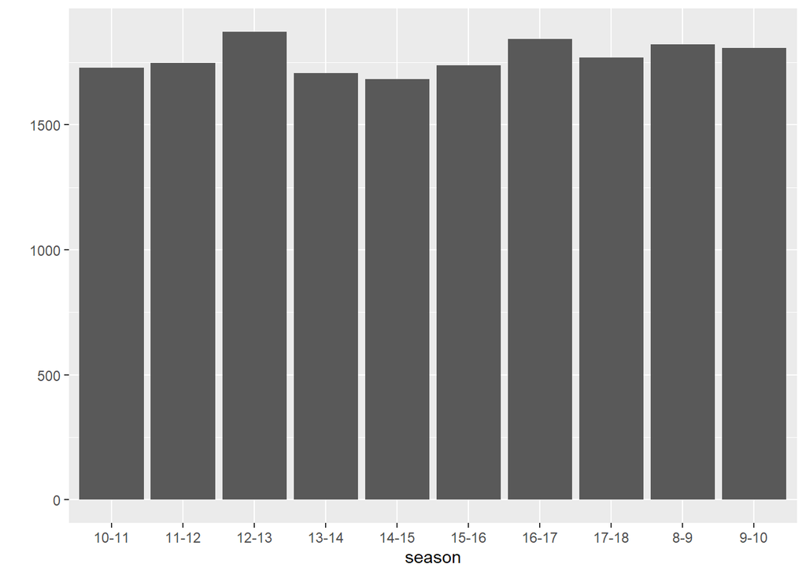

Plot season against date.:

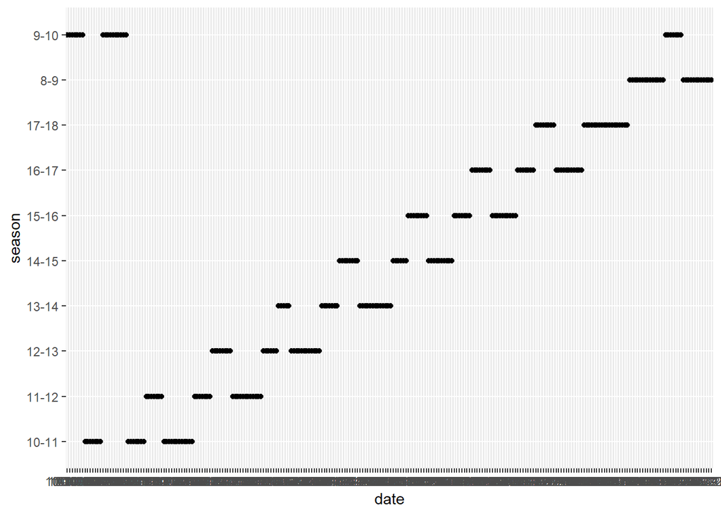

```r
library(ggplot2)
ggplot2::ggplot(aes(x=date,y=season),data=dat)+geom_point()
```

#Season vs date Check for unique values

```r
cor.test(as.numeric(dat$date),as.numeric(dat$season),method = "spearman")
```

```
##
##  Spearman's rank correlation rho
##
## data:  as.numeric(dat$date) and as.numeric(dat$season)
## S = 3.2829e+11, p-value < 2.2e-16
## alternative hypothesis: true rho is not equal to 0
## sample estimates:
##       rho
## 0.6459875
```

There is high correlation between date and season Though to this, i will use season to check its relation with speed.

```r
length(unique(dat$date)) #254 unique dates
```

```
## [1] 254
```

```r
length(unique(dat$season))#10 unique season
```

```
## [1] 10
```

#Season data grouping

```r
library(dplyr)
```

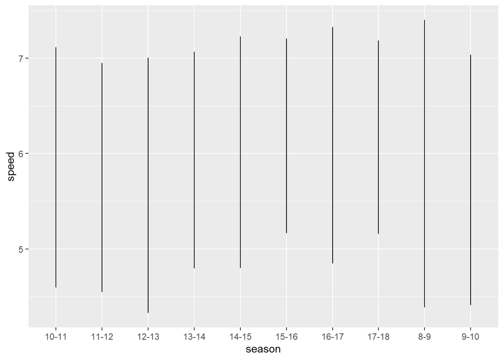

```r
season_data <- function(){
  dat%>%
    group_by(season)%>%
    arrange(season)
}
ggplot(aes(x=season,y=speed),data=season_data())+geom_line()
```

#Speed vs season

```r
cor.test(as.numeric(dat$season), dat$speed)
```

```
##
##  Pearson's product-moment correlation
##
## data:  as.numeric(dat$season) and dat$speed
## t = 9.9067, df = 17718, p-value < 2.2e-16
## alternative hypothesis: true correlation is not equal to 0
## 95 percent confidence interval:
##  0.05956155 0.08884709
## sample estimates:
##        cor
## 0.07422032
```

season does’t affect speed. #speed vs age

```r
speed_age <- function(){
  dat%>%
    group_by(speed)%>%
    summarise(age_mean=round(mean(age)),
            age_median=round(median(age),),
            speed_mean=round(mean(speed),0.5),
            n=n())%>%
    arrange(speed_mean)
}
speed_age()
```

```
## # A tibble: 7,790 x 5
##    speed age_mean age_median speed_mean     n
##    <dbl>    <dbl>      <dbl>      <dbl> <int>
##  1  4.33       21         21        4.3     1
##  2  4.39       20         20        4.4     1
##  3  4.41       22         22        4.4     1
##  4  4.43       23         23        4.4     1
##  5  4.49       21         21        4.5     1
##  6  4.53       21         21        4.5     1
##  7  4.53       44         44        4.5     1
##  8  4.53       23         23        4.5     1
##  9  4.54       22         22        4.5     1
## 10  4.55       20         20        4.6     1
## # ... with 7,780 more rows
```

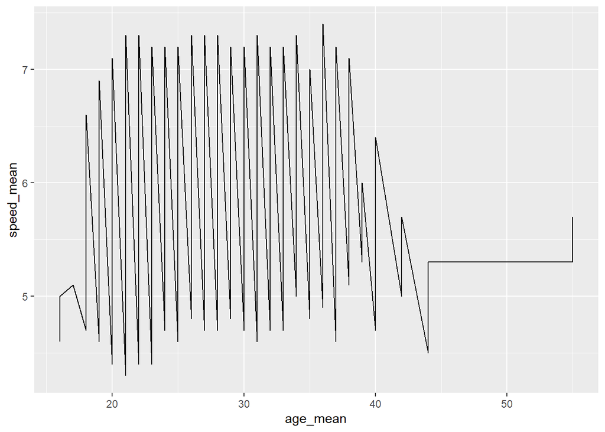

```r
ggplot(aes(x=age_mean,y=speed_mean),data=speed_age())+geom_line()
```

As seen in the above graph, the prime speed is between 22 and 38 years.

```r
cor.test(speed_age()$age_mean, speed_age()$speed_mean)
```

```
##
##  Pearson's product-moment correlation
##
## data:  speed_age()$age_mean and speed_age()$speed_mean
## t = 20.423, df = 7787, p-value < 2.2e-16
## alternative hypothesis: true correlation is not equal to 0
## 95 percent confidence interval:
##  0.204288 0.246448
## sample estimates:
##       cor
## 0.2254736
```

positive correlation between speed and age. now split into ranges. # we will choose age between 22 and 38 as affecting speed most

##speed vs rank

```r
rank_data <- function(){
  cor.test(dat$rank,dat$speed)
  qplot(dat$rank,dat$speed)
}
```

Higer speed is better, means you run faster, lower rank is beteer, means you are ranked higher, like 1 being the highest.

this is the reason for the high negative correlation of -0.45

#course.rank vs speed

```r
course.rank_data <-function(){
  cor.test(dat$course.rank,dat$speed)
}
```

course rank has higher effect on speed than rank. with a correlation of -0.54 meaning the person ranked 1st in course rank will have higher speed.

Faster people are ranked higher, thus negative correlation. #country vs speed nation variable has 42 levels meaning 42 different countries.

```r
country_data <-function(){
  dat%>%
    group_by(nation)%>%
    summarise(speed_mean=mean(speed),
            speed_median=mean(speed))%>%
    arrange(speed_mean)

}
country_data()
```

```
## # A tibble: 42 x 3
##    nation speed_mean speed_median
##    <fct>       <dbl>        <dbl>
##  1 TUR          4.64         4.64
##  2 AUS          5.11         5.11
##  3 GRL          5.23         5.23
##  4 CRO          5.36         5.36
##  5 BRA          5.41         5.41
##  6 NZL          5.44         5.44
##  7 NED          5.51         5.51
##  8 GRE          5.51         5.51
##  9 BIH          5.57         5.57
## 10 GBR          5.64         5.64
## # ... with 32 more rows
```

Germany (GER) has the highest speed will TUR has the lowest speed.

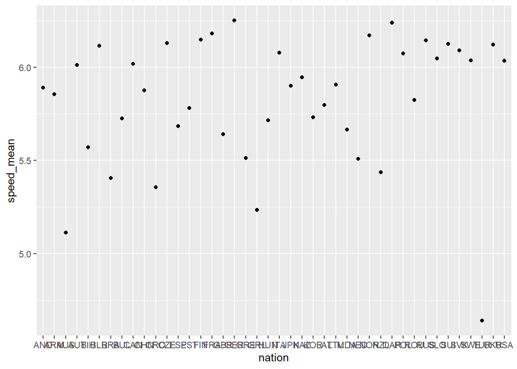

```r
ggplot(aes(x=nation,y=speed_mean),data=country_data())+geom_point()
```

```r
cor.test(as.numeric(country_data()$nation),country_data()$speed_mean)
```

```
##
##  Pearson's product-moment correlation
##
## data:  as.numeric(country_data()$nation) and country_data()$speed_mean
## t = 0.91437, df = 40, p-value = 0.366
## alternative hypothesis: true correlation is not equal to 0
## 95 percent confidence interval:
##  -0.1681576  0.4283881
## sample estimates:
##       cor
## 0.1430867
```

This shows that country has little effect on speed though coming to a country with higher speed average increases your chances of speed improvement marginally.

#snow.condition

```r
snow.condition_data <-function(){
  dat%>%
    group_by(snow.conditions)%>%
    summarise(speed_mean=mean(speed),
            speed_median=mean(speed))%>%
    arrange(speed_mean)


}
snow.condition_data()
```

```
## # A tibble: 15 x 3
##    snow.conditions      speed_mean speed_median
##    <fct>                     <dbl>        <dbl>
##  1 Wet and powder             5.16         5.16
##  2 powder                     5.53         5.53
##  3 Wet & powder               5.56         5.56
##  4 Powder                     5.75         5.75
##  5 Packed powder              5.87         5.87
##  6 Wet                        5.93         5.93
##  7 Hard packed                5.97         5.97
##  8 Hard packed variable       5.98         5.98
##  9 Hard Packed Variable       6.01         6.01
## 10 Granular                   6.01         6.01
## 11 Packed                     6.08         6.08
## 12 Soft                       6.16         6.16
## 13 Hard                       6.25         6.25
## 14 Compact                    6.29         6.29
## 15 Hard Packed                6.37         6.37
```

We need to make more adjustment to the data as a some values are written differently. we can use mutate method in dyplr to mearge the values. #

```r
cor.test(as.numeric(dat$snow.conditions),dat$speed)
```

```
##
##  Pearson's product-moment correlation
##
## data:  as.numeric(dat$snow.conditions) and dat$speed
## t = -35.428, df = 17718, p-value < 2.2e-16
## alternative hypothesis: true correlation is not equal to 0
## 95 percent confidence interval:
##  -0.2708984 -0.2433984
## sample estimates:
##        cor
## -0.2572005
```

’plot snow condition

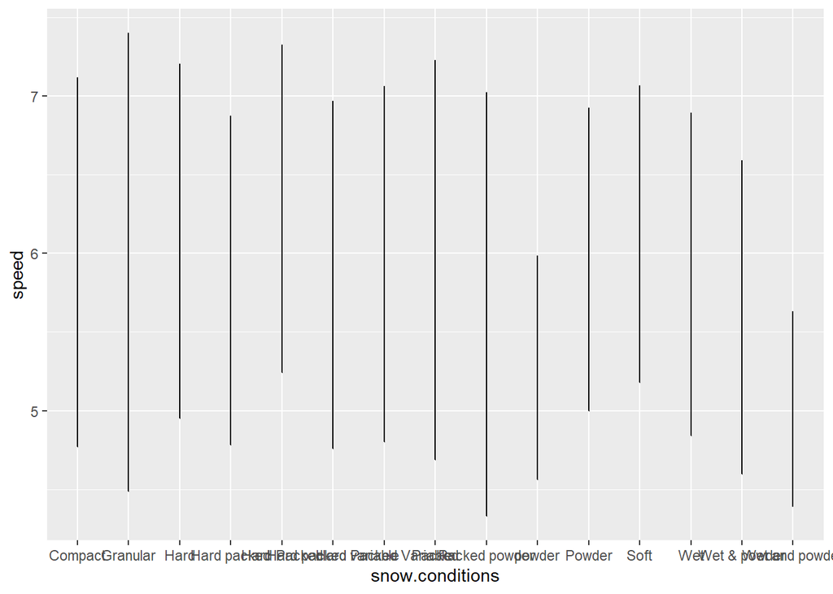

```r
ggplot(aes(x=snow.conditions,y=speed),data=dat)+geom_line()
```

```r
#this shows some seasonality
```

#comparing Snow condition, air.temperature, speed,snow.temperature.

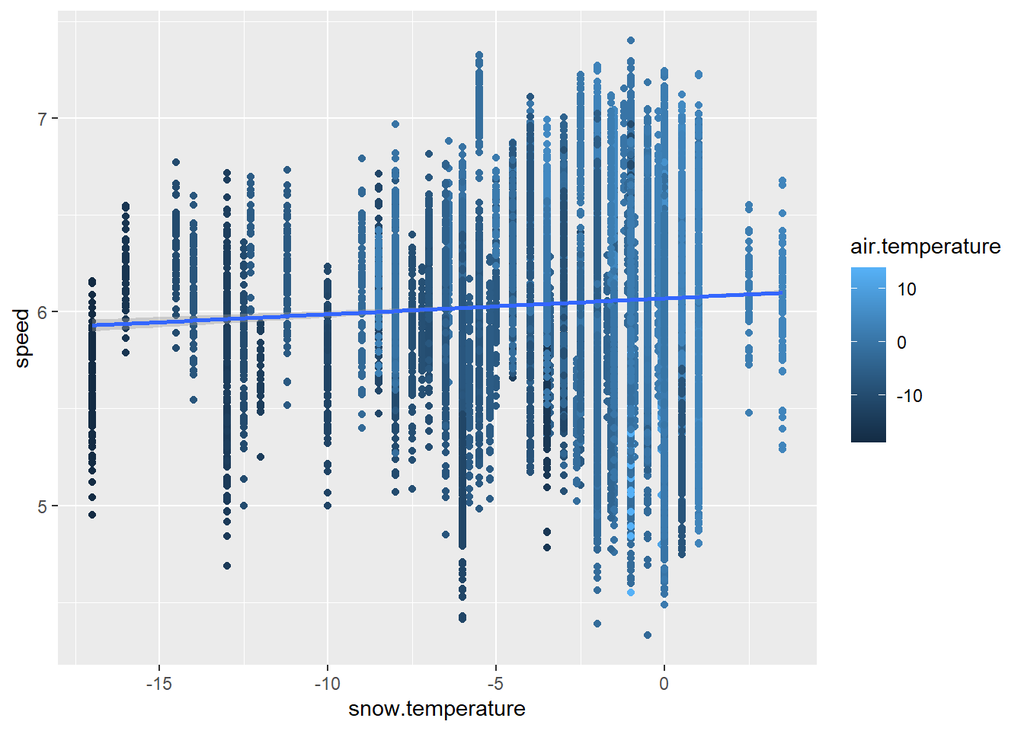

```r
four_var_data <-function(){
  ggplot(data=dat,mapping=aes(x=snow.temperature,y=speed),color=
         snow.conditions)+geom_point(mapping=aes(color=air.temperature))+geom_smooth(method = "lm")



}
four_var_data()
```

As seen from the data above, Increase in temperature results to increase in speed but also variability also increases. also higher air temperature has positive correlation with high snow temperature.

you need air temperature and snow temperature to increase to about 0 degrees for higher speed but this can also result in low speed.

#Weather condition, speed, age

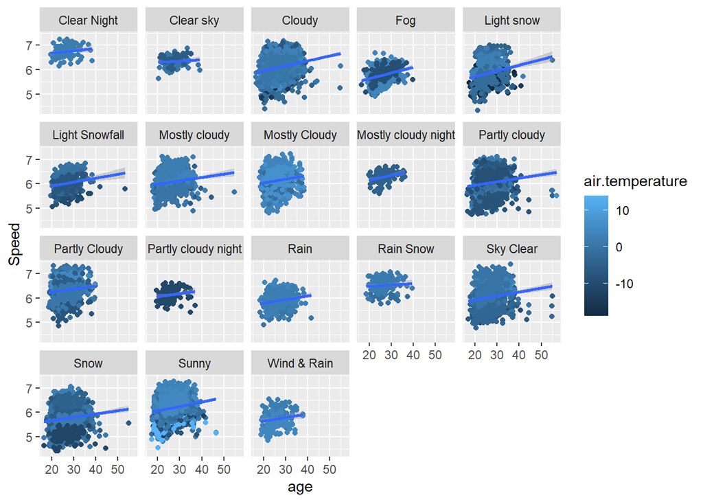

```r
weather_age_speed <- function(){
  ggplot(data=dat, aes(x=age,y=speed))+geom_point(aes(color= air.temperature))+ geom_smooth(method = "lm")+facet_wrap(~weather.conditions)+labs(x="age",y="Speed")
}
weather_age_speed()
```

#Correlation

```r
cor(dat[,c("snow.temperature","air.temperature","fails.total","age","speed","rank","course.rank","elevation","max.climb", "tot.time","total.climb","course.time")])
```

```
##                  snow.temperature air.temperature fails.total age        speed
## snow.temperature      1.000000000     0.666256976 -0.03286427  NA  0.060902415
## air.temperature       0.666256976     1.000000000 -0.03229544  NA  0.189419867
## fails.total          -0.032864269    -0.032295443  1.00000000  NA -0.138042615
## age                            NA              NA          NA   1           NA
## speed                 0.060902415     0.189419867 -0.13804261  NA  1.000000000
## rank                 -0.006272291    -0.003320968  0.38839797  NA -0.453275202
## course.rank          -0.009715640    -0.004029065  0.04075068  NA -0.540180800
## elevation             0.115846042     0.260721605 -0.03873363  NA -0.004693423
## max.climb                      NA              NA          NA  NA           NA
## tot.time             -0.081618098    -0.056465994  0.42428254  NA -0.221060381
## total.climb                    NA              NA          NA  NA           NA
## course.time          -0.102370423    -0.050078453  0.35606420  NA -0.277411700
##                          rank  course.rank    elevation max.climb    tot.time
## snow.temperature -0.006272291 -0.009715640  0.115846042        NA -0.08161810
## air.temperature  -0.003320968 -0.004029065  0.260721605        NA -0.05646599
## fails.total       0.388397972  0.040750679 -0.038733631        NA  0.42428254
## age                        NA           NA           NA        NA          NA
## speed            -0.453275202 -0.540180800 -0.004693423        NA -0.22106038
## rank              1.000000000  0.838104805  0.039539013        NA -0.01425569
## course.rank       0.838104805  1.000000000  0.040022594        NA -0.02180534
## elevation         0.039539013  0.040022594  1.000000000        NA -0.02137141
## max.climb                  NA           NA           NA         1          NA
## tot.time         -0.014255686 -0.021805343 -0.021371414        NA  1.00000000
## total.climb                NA           NA           NA        NA          NA
## course.time       0.025961159  0.062340105 -0.036872569        NA  0.86227943
##                  total.climb course.time
## snow.temperature          NA -0.10237042
## air.temperature           NA -0.05007845
## fails.total               NA  0.35606420
## age                       NA          NA
## speed                     NA -0.27741170
## rank                      NA  0.02596116
## course.rank               NA  0.06234011
## elevation                 NA -0.03687257
## max.climb                 NA          NA
## tot.time                  NA  0.86227943
## total.climb                1          NA
## course.time               NA  1.00000000
```

```r
cor.test(as.numeric(dat$weather.conditions),dat$speed)
```

```
##
##  Pearson's product-moment correlation
##
## data:  as.numeric(dat$weather.conditions) and dat$speed
## t = -7.3569, df = 17718, p-value = 1.965e-13
## alternative hypothesis: true correlation is not equal to 0
## 95 percent confidence interval:
##  -0.06985228 -0.04049422
## sample estimates:
##         cor
## -0.05518518
```